# Intervalos Bootstrap

María Belén Rosero, Lizeth Moreno

2020/01/11

# Introducción

Un intervalo de confianza es una técnica para estimar resultados, pues permite acotarlos mediante un par de valores dentro de los cuales se encontrará la estimación puntual que se desee.

Una manera de mejorar los intervalos, es decir tener una mejor aproximación mediante los intervalos bootstrap.

Gracias al método bootstrap se pueden obtener intervalos ajustados sin necesidad de asumir normalidad en los datos.

Para ello procede mediante remuestreo, es decir, obteniendo muestras mediante algún procedimiento aleatorio que utilice la muestra original.

Ahora, vamos a obtener por los 4 métodos, los intervalos, la Cobertura y la longitud de los siguientes ejemplos.

# Ejemplo para n<30

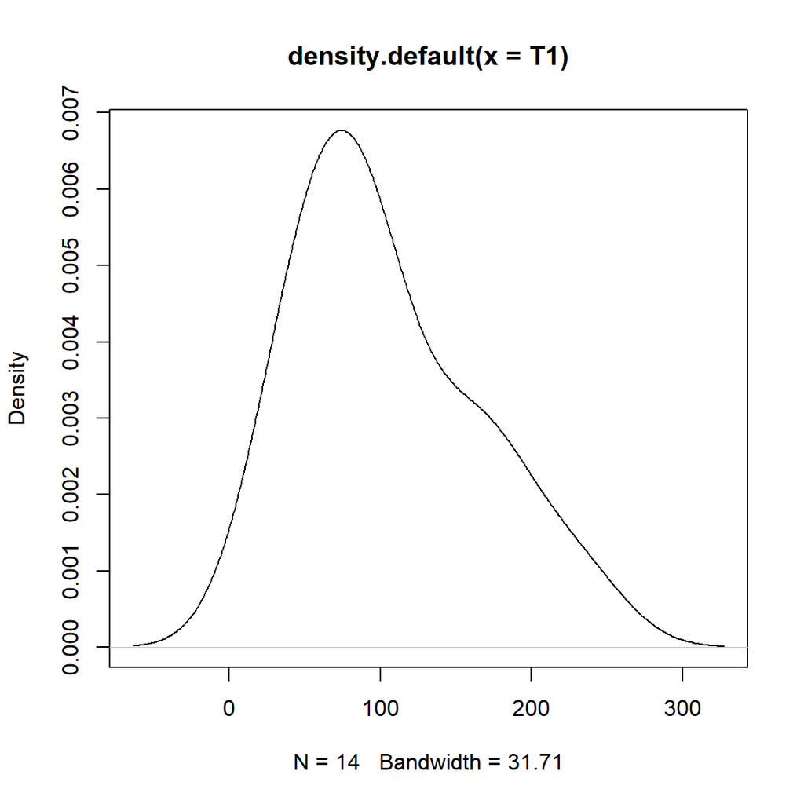

```r
caj4353<-data_banco[data_banco$Cajero=="4353",]
T1<-caj4353$Tiempo_Servicio_seg
plot(density(T1))
```

```r
shapiro.test(T1)
```

```
    Shapiro-Wilk normality test

data:  T1
W = 0.92478, p-value = 0.2575
```

|  | Normal | Percentil | Percentil-t | Percentil-t simetrizado |
| --- | --- | --- | --- | --- |
| Cobertura | 0.9240 | 0.88600 | 0.96000 | 0.96000 |
| Longitud | 59.0521 | 56.27034 | 71.50867 | 72.00855 |

Como podemos observar la cobertura que más se aproxima al valor real del 95% esta dado por el Percentil-t y Percentil-t Simetrico

# Ejemplo muestra normal $N(0,1)$ de tamaño 25

Consideremos una muestra de una distribución normal $N(0,1)$ de tamaño 25.

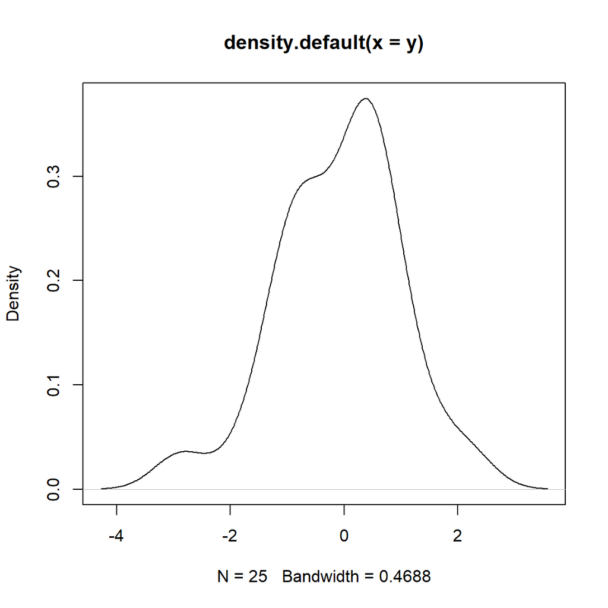

```
      2.5%      97.5%
-0.5295427  0.3632980
```

```
    One Sample t-test

data:  y
t = -0.38608, df = 24, p-value = 0.7028
alternative hypothesis: true mean is not equal to 0
95 percent confidence interval:
 -0.5274788  0.3612341
sample estimates:
  mean of x
-0.08312235
```

```
   user  system elapsed
  22.69    0.03   22.79
```

|  | Normal | Percentil | Percentil-t | Percentil-t simetrizado |
| --- | --- | --- | --- | --- |
| Cobertura | 0.93800 | 0.92800 | 0.94000 | 0.94600 |
| Longitud | 38.72876 | 38.24116 | 40.38271 | 40.72145 |

Como podemos observar la cobertura que más se aproxima al valor real del 95% esta dado por el Percentil-t Simetrico.

# Ejemplo para Sucursal Riocentro Sur

El siguiente ejemplo para la Sucursal Riocentro Sur para la Transacción Cobro/Pago(Cta externa) además por tipo transacción Bueno.

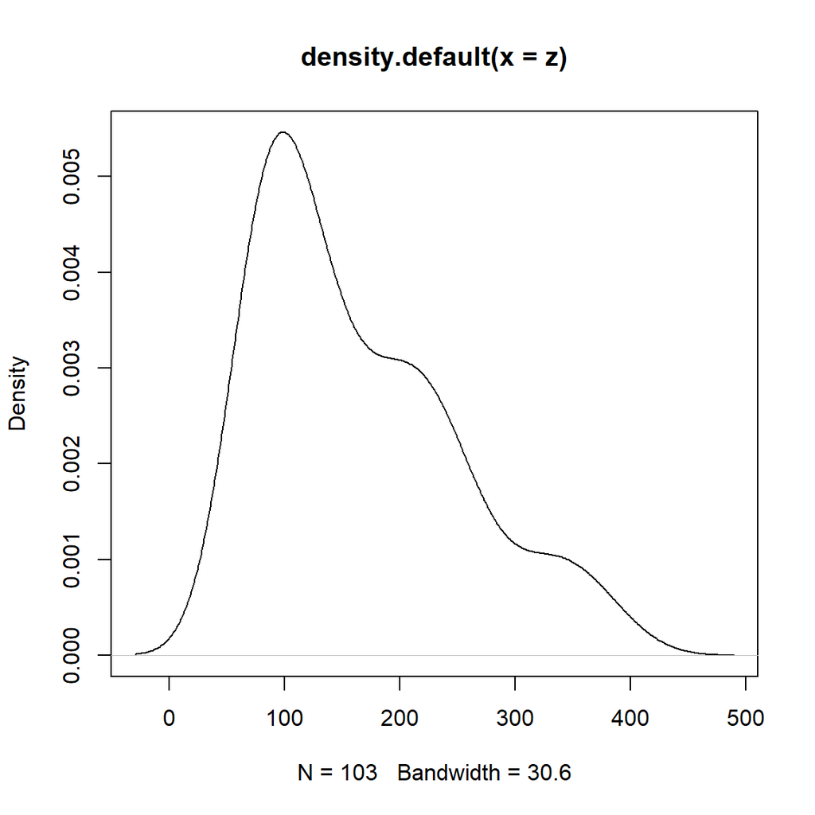

```
    2.5%    97.5%
148.0840 181.2753
```

```
    One Sample t-test

data:  z
t = 19.451, df = 102, p-value < 2.2e-16
alternative hypothesis: true mean is not equal to 0
95 percent confidence interval:
 147.8868 181.4725
sample estimates:
mean of x
 164.6796
```

```
   user  system elapsed
  23.85    0.08   24.15
```

[output not shown]

En este caso de muestra se puede notar que la cobertura se aproxima a $0.95$ en el caso de Percentil-t Simétrico.

# Ejemplo Cajero 2230

Consideramos el tiempo de transacción de ‘Cobrar cheque (Cta del Bco)’ del cajero ‘2230’

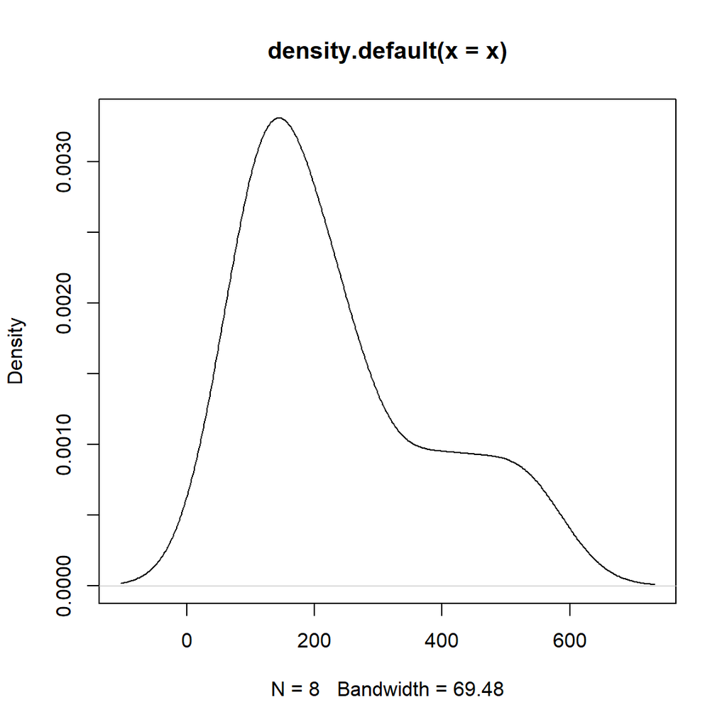

```
     2.5%     97.5%
 25.97938 444.12570
```

```
    One Sample t-test

data:  x
t = 4.3996, df = 7, p-value = 0.003159
alternative hypothesis: true mean is not equal to 0
95 percent confidence interval:
 108.719 361.386
sample estimates:
mean of x
 235.0525
```

```
   user  system elapsed
  22.67    0.08   22.95
```

[output not shown]

Como podemos observar la cobertura que más se aproxima al valor real del $(95\%)$ esta dado por el Percentil-t Simetrico